# Lecture Overview

This tutorial aims to serve as an introduction to the software package **R**. If you do not have any programming experience, I recommend having a look at https://www.datacamp.com/courses/free-introduction-to-r (also available in German and some other languages).

**Objective of our course:** review basic methods and models from econometrics and implement them in **R**. We need the **R** implementation in order to be able to evaluate different methods based on their finite sample properties.

## Data

We will use (in most cases) simulated data:

- it allows us to control the data generating process (normality, homoskedasticity, linearity, etc.);
- we can manipulate properties of the DGP to evaluate different estimators.

## Why R?

- R is **free** of charge from: [www.r-project.org](https://www.r-project.org/)
- Graphics in R are very flexible and powerful.
- The main editor **RStudio** for R is also **free** of charge: [www.rstudio.com](http://www.rstudio.com/)
- Today, R is the de-facto standard for statistical science.

## How to install R?

- The easiest way is to install it through The Comprehensive R Archive Network (CRAN). Just visit the CRAN downloads page: [cran.r-project.org](https://cran.r-project.org/) and follow the instructions there. You will need to choose a mirror, however, there is basically no difference between them. You are free to choose whichever you like more.
- Afterwards, you will need an Integrated development environment (IDE): for example, RStudio. It includes a console that supports direct code execution and tools for plotting and keeping track of your variables in the workspace, among other features. The installation process is very straightforward as well. Simply go to the RStudio downloads page: rstudio.com/products/rstudio/download/ and follow the isntructions there.

**Important:** first install R and only then RStudio!

## Other materials

Other very good and much more exhaustive tutorials and other useful tools can be found at:

- Econometrics with R:  
  cran.r-project.org/doc/contrib/Farnsworth-EconometricsInR.pdf
- Reference card for R commands (always useful!):  
  cran.r-project.org/doc/contrib/refcard.pdf
- Matlab/R reference card (for those who are more familiar with Matlab):  
  umaine.edu/mathematics/wp-content/uploads/sites/70/2018/08/matlabR.pdf
- Very detailed official Introduction to R:  
  cran.r-project.org/doc/manuals/r-release/R-intro.pdf
- And many more at  
  www.r-project.org/other-docs.html
- An interactive R-package for learning R:  
  [swirlstats.com](https://swirlstats.com/)
- An excellent book project which covers also advanced issues such as "writing performant code" and "package development":  
  [adv-r.had.co.nz](http://adv-r.had.co.nz/)
- Another excellent book, R for Data Science:  
  [r4ds.had.co.nz](https://r4ds.had.co.nz/)

**An Example: Density estimation**

Suppose that $X_i \sim \mathcal{N}(0,1)$. We would like to compare a randomly chosen sample $\{X_1, \ldots, X_N\}$ with the theoretical values of the normal distribution.

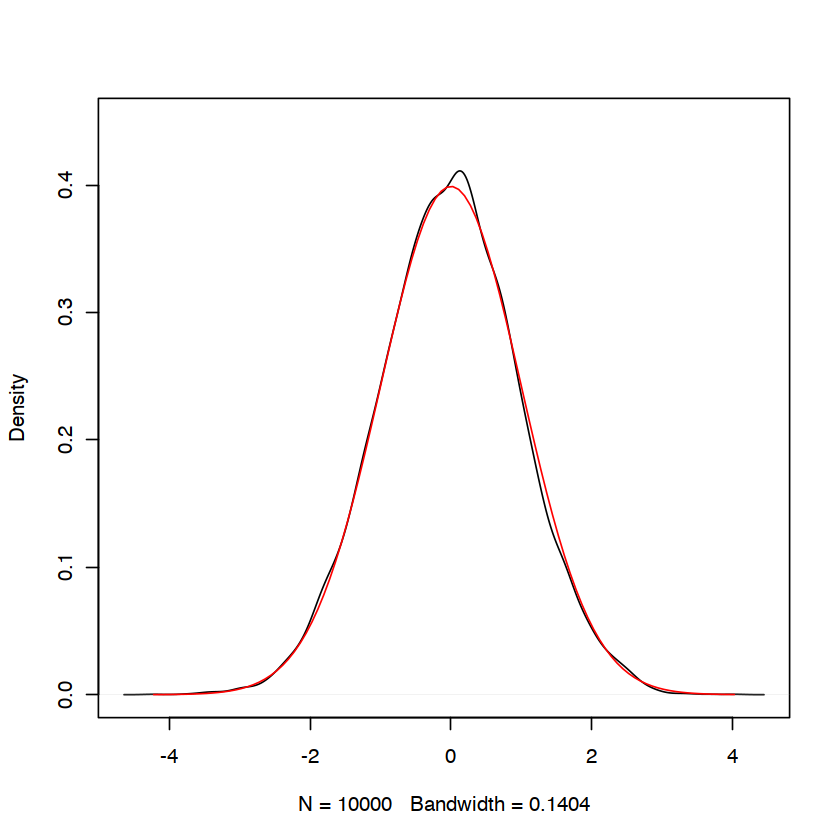

```r
N  <- 10000 #Number of observations in the draw
x  <- rnorm(N, mean = 0, sd = 1)
z  <- seq(min(x), max(x), le = 100)
hx <- dnorm(z)
plot(density(x), main = "", ylim = c(0,0.45))
lines(z, hx, col="red")
```

[figure not shown]

# R Introduction

## Short Glossary

Lets start the tutorial with a (very) short glossary:

- *[Console]*: The main part where the code is executed. It starts with the "**>**" sign.
- *[Script file]*: An ordinary text file with suffix "**.R**" or "**.r**". For instance, **example_1.R**.
- *[Working directory]*: The file-directory you are working in. If, for example, when loading data, the location is not explicitly specified, then R assumes that the data is in the *[working directory]*. However, the working directory can be set arbitrarily, which is a frequent source of errors. Useful commands: with `getwd()` you get the location of your current working directory and `setwd()` allows you to set a new location for it.
- *[Workspace]*: This is a hidden file (stored in the working directory as "**.RData**"), where all objects you use (e.g., data, matrices, vectors, variables, functions, etc.) are stored. When you close your R session, you will be asked whether you want to save or delete the *[workspace]* of the session. If you say "Yes", the saved workspace will be loaded automatically together with the next R session (if you start R in the same working directory). Useful commands: `ls()` shows all elements in our current workspace and `rm(list=ls())` deletes all elements in our current workspace.

## Operators

A good idea is to use a script file such as **helloworld.R** in order to store your R commands. You can send single lines or marked regions of your R-code to the console by pressing the keys **Shift+ENTER**.

We start with basic arithmetic operations:

+, -, *, /

Remmeber, we write 1.8 not 1,8

Exponents are declared with ^, i.e. $2^3$ is written as

2^3

For mathematical calculations, only parentheses `()` can be used. Frequently used mathematical functions (and constants) are

- `sqrt()` – square root;
- `exp()` – exponential function;
- `log()` – natural logarithm;
- `log(..., 10)` – logarithm with base 10;
- `abs()` – absolute value;
- `round(...,x)` – rounding to x decimals;
- `pi` – constant $\pi$;
- `exp(1)` – Eulers number $e$;
- `sin()`, `cos()`, `tan()` – trigonemetric functions;
- `min()`, `max()` – smallest/biggest value of a vector/matrix.

```r
1.8 + 2
 1.8 - 2
 1.8 * 2
 1.8 / 2
 2 + 2 * 3
 (2 + 2) * 3
 2^3
 8^(1 / 3)
 3^2
 9^0.5
 2^2 * 2 + 2
 2^(2*((0.2 + 0.3)*(1 + 2))) + 4
 sqrt(2)
 exp(1)
 exp(2)
 log(7.389056)
 log(exp(3))
 log(100, 10)
 abs(1.8 - 2)
 round(sqrt(2), 2)
 round(sqrt(2), 4)
 pi
 sin(pi / 2)
 cos(pi / 2)
 sin(pi)
 tan(pi)
 x <- 2 + 3i
 y <- 4 + 1i
 x
 y
 x + y
 x * y
```

3.8

-0.2

3.6

0.9

8

12

8

2

9

3

10

12

1.4142135623731

2.71828182845905

7.38905609893065

1.99999998661119

3

2

0.2

1.41

1.4142

3.14159265358979

1

6.12323399573677e-17

1.22464679914735e-16

-1.22464679914735e-16

2+3i

4+1i

6+4i

5+14i

**Attention:**

1.224606e-16 is interpreted as $1.224606 \times 10^{-16}$. This is often exactly zero, but for internal memory purposes (R only has up to 16 decimals), can be a rounding mistake.

*Note: Everything that is written after the `#`-sign is ignored by R, so use it to comment your code.*

**A note on good practices: Always comment your code!**

```r
#hello
```

```r
# hello, this is my first comment
```

```r
y <- 10 #here I define y as 1
```

```r
y
```

10

[figure not shown]

The assignment operator `"<-"` will be your most often used tool. Here is an example on how to create a **scalar** variable and assign the value $4$ to it:

```r
x <- 4
x
z = 3
z
4 -> y # possible but unusual
y
```

4

3

4

*Note: The R community loves the `<-` assignment operator, which is a very unusual syntax. Alternatively, you can use the `=` operator.*

The command `ls()` shows the total content of your current workspace, and the command `rm(list=ls())` deletes all elements of your current workspace:

```r
ls()
a
```

1. 'N'

2. 'hx'

3. 'x'

4. 'y'

5. 'z'

```
Error in eval(expr, envir, enclos): объект 'a' не найден
Traceback:
```

```r
rm(list = ls())
ls()
x
```

```
Error in eval(expr, envir, enclos): объект 'x' не найден
Traceback:
```

*Note:* *[Environment]* panel in RStudio also lists all the elements in your current workspace. That is, the command `ls()` becomes a bit obsolete when working with RStudio.

## Numerical and non-numeric objects

Non-numeric data in R is often preceded by quotation marks "" or '' and can also be identified by these in the output.

```r
x <- 2
x
```

2

```r
y <- x + 14
y/2
```

8

```r
x <- "2"
x
typeof(x)
```

'2'

'character'

```r
x + 1
```

```
Error in x + 1: нечисловой аргумент для бинарного оператора
Traceback:
```

```r
is.numeric(x)
```

FALSE

```r
x <- z
```

```
Error in eval(expr, envir, enclos): объект 'z' не найден
Traceback:
```

```r
x <- "z"
x
```

'z'

```r
sqrt(4)
```

2

## Data structures: vectors, matrices, lists

### Vectors

If you want to store several numbers or names (string) under an object name, the construction of a vector is a good idea. Vectors are created using the command `c()` where "c" stands for "combine". There exist other ways of creating a vector as well. Compute the following commands for vectors:

```r
a <- c(1, 2, 3)
a
```

1. 1

2. 2

3. 3

```r
b <- c(2, 3, 4)
b
```

1. 2

2. 3

3. 4

```r
a + b
```

1. 3

2. 5

3. 7

```r
a /b
```

1. 0.5

2. 0.666666666666667

3. 0.75

We can also perform vector (and a little later matrix) multiplication, e.g., an outer product: $y\cdot y^\top$:

```r
y <- c(1, 2, 3)
y %*% t(y)
```

A matrix: 3 × 3 of type dbl

| 1 | 2 | 3 |
| --- | --- | --- |
| 2 | 4 | 6 |
| 3 | 6 | 9 |

Or an inner product $y^\top \cdot y$:

```r
result <- t(y) %*% y
typeof(result)
result
```

'double'

A matrix: 1 × 1 of type dbl

| 14 |
| --- |

*Note: Sometimes, R's treatment of vectors can be annoying. The product* `y %*% y` *is treated as the product* `t(y) %*% y`.

```r
a %*% b
```

A matrix: 1 × 1 of type dbl

| 20 |
| --- |

```r
b %*% a
```

A matrix: 1 × 1 of type dbl

| 20 |
| --- |

```r
v1 <- c(a, b)
v1
v2 <- c(1, 2, 3)
v2
v3 <- c(v1, 4, 5)
v3
v4 <- c(c(4, 2, 3), v3, c(3, 8), 1, 2, c(v1, v2, v3))
v4
v <- c()
v
v <- c(v, 4)
v
v <- c(v, 10)
v
```

1. 1

2. 2

3. 3

4. 2

5. 3

6. 4

1. 1

2. 2

3. 3

1. 1

2. 2

3. 3

4. 2

5. 3

6. 4

7. 4

8. 5

1. 4

2. 2

3. 3

4. 1

5. 2

6. 3

7. 2

8. 3

9. 4

10. 4

11. 5

12. 3

13. 8

14. 1

15. 2

16. 1

17. 2

18. 3

19. 2

20. 3

21. 4

22. 1

23. 2

24. 3

25. 1

26. 2

27. 3

28. 2

29. 3

30. 4

31. 4

32. 5

4

1. 4

2. 10

```r
Name <- c("Anton", "Berta", "Caesar", "Dora", "Emil")
Gender <- c("m", "w", "m", "w", "m")
Height <- c(182, 174, 189, 165, 180)
Weight <- c(80, 68, 92, 55, 78)
Name
Gender
Height
Weight
```

1. 'Anton'

2. 'Berta'

3. 'Caesar'

4. 'Dora'

5. 'Emil'

1. 'm'

2. 'w'

3. 'm'

4. 'w'

5. 'm'

1. 182

2. 174

3. 189

4. 165

5. 180

1. 80

2. 68

3. 92

4. 55

5. 78

In practice, it often happens that the values of a vector follow a particular basic pattern. For example, the difference between two neighbouring values is constant or we are interested in a vector with exactly the same values. In this case the commands `seq()` and `rep()` are very helpful. With the operator `:` shortened sequences with step size 1 can be generated. If the end value does not fit into the sequence of the generated sequence, the next lower (or next larger) value is aborted.

```r
c <- 0:20
c
```

1. 0

2. 1

3. 2

4. 3

5. 4

6. 5

7. 6

8. 7

9. 8

10. 9

11. 10

12. 11

13. 12

14. 13

15. 14

16. 15

17. 16

18. 17

19. 18

20. 19

21. 20

```r
seq(2, 31, by = 4)
```

1. 2

2. 6

3. 10

4. 14

5. 18

6. 22

7. 26

8. 30

```r
seq(2, 30, le = 6)
```

1. 2

2. 7.6

3. 13.2

4. 18.8

5. 24.4

6. 30

```r
rep(1, 3)
```

1. 1

2. 1

3. 1

```r
v1
rep(v1, each = 3)
```

1. 1

2. 2

3. 3

4. 2

5. 3

6. 4

1. 1

2. 1

3. 1

4. 2

5. 2

6. 2

7. 3

8. 3

9. 3

10. 2

11. 2

12. 2

13. 3

14. 3

15. 3

16. 4

17. 4

18. 4

```r
v1 <- seq(1, 30, by = 10)
v1
```

1. 1

2. 11

3. 21

The individual components of a vector $x$ are numbered from $1$ to $n$, where $n$ is the total number of the components, i.e. vector length. The length of the vector $x$ can be queried with `length(x)`. You can access the elements of the vector using so-called indexing vectors and the square brackets.

```r
length(c)
```

21

```r
v1[2]
v1[c(1, 2)]
v1[c(TRUE, FALSE, FALSE)]
```

11

1. 1

2. 11

1

Most of the times, we will be using vectors together other vectors of the same length or a scalar. In the first case, computations are performed componentwise. In the second case, the computation is performed separately on each of the elements of the vector. For example,

```r
c(1, 2, 3) + 5
```

1. 6

2. 7

3. 8

If two vectors of unequal length (each with at least 2 components) are added, a warning message is usually issued. R will still perform the operation though!

```r
a <- c(1, 2, 3, 4, 5)
b <- c(1, 2, 3)
a + b
```

```
Warning message in a + b:
“длина большего объекта не является произведением длины меньшего объекта”
```

1. 2

2. 4

3. 6

4. 5

5. 7

How does this result come about? R proceeds here according to the recycling rule:

*If two vectors are of unequal length, the shorter one will be recycled in order to match the longer vector*.

For example, with two objects of different lengths, the shorter object is used multiple times in order to match the length of the longer object. In this example, the first two elements `1` and `2` of the vector `c(1,2,3)` are attached to its end so that in the end we have `c(1, 2, 3, 1, 2)`. Beware, if the longer object's length **is** a multiple of a shorter object's length, no warning message is issued!

```r
a1 <- c(1, 2, 3, 4, 5, 6)
b1 <- c(1, 2, 3)
a1 + b1
```

1. 2

2. 4

3. 6

4. 5

5. 7

6. 9

> **Exercise**: Basic vector operations
> - Generate $x = [3\, 6\, 8]$.
> - Calculate $x/2$, $x^2$, $\sqrt{x}$.
> - Display the second element of $x$.
> - Create a vector with the first and the third element of $x$.
> - Remove the third elmement from $x$.
> - Generate $y = [2\, 5\, 1]$.
> - Calculate `x - y`, `x * y` and `t(x)%*%y` and `x%*%t(y)`.
> - Display all elements of $x$ for which the corresponding element of $y$ is larger than $1.5$.
> - Display all element(s) of $y$ for which the corresponding element in $x$ is equal to $6$.
> - Generate a vector of integers from $4$ to $10$.
> - Using `seq()` and `rep()`, (a) generate a vector ranging from $2$ to $3$ with a step of $0.1$, (b) generate a vector that repeats the elements of $x$ 4 times, i.e. the first four elements of the new vector are four times the first element of $x$, etc.

```r
x <- c(3, 6, 8)
x
x / 2
x^2
sqrt(x)
x[2]
x[c(1,3)]
x[-3]
y <- c(2, 5, 1)
y
x - y
x * y
t(x) %*% y
(x) %*% t(y)
x[1] * y[1] + x[2] * y[2] + x[3] * y[3]
x[y > 1.5]###Elements of x, for which y is larger than 1.5
y[x == 6]##Element of y for which the element in x is equal to 6.
4:10
seq(2, 3, by = 0.1)
rep(x, each = 4)
```

1. 3

2. 6

3. 8

1. 1.5

2. 3

3. 4

1. 9

2. 36

3. 64

1. 1.73205080756888

2. 2.44948974278318

3. 2.82842712474619

6

1. 3

2. 8

1. 3

2. 6

1. 2

2. 5

3. 1

1. 1

2. 1

3. 7

1. 6

2. 30

3. 8

A matrix: 1 × 1 of type dbl

| 44 |
| --- |

A matrix: 3 × 3 of type dbl

| 6 | 15 | 3 |
| --- | --- | --- |
| 12 | 30 | 6 |
| 16 | 40 | 8 |

44

1. 3

2. 6

5

1. 4

2. 5

3. 6

4. 7

5. 8

6. 9

7. 10

1. 2

2. 2.1

3. 2.2

4. 2.3

5. 2.4

6. 2.5

7. 2.6

8. 2.7

9. 2.8

10. 2.9

11. 3

1. 3

2. 3

3. 3

4. 3

5. 6

6. 6

7. 6

8. 6

9. 8

10. 8

11. 8

12. 8

### Matrices

In the following, we will discuss how matrices in R are constructed and how we can work with them.

The basic command for constructing matrices is `matrix()`.

In most cases, the input of three arguments is sufficient:

- a data vector from which a matrix is constructed,
- the number of rows,
- the number of columns.

As a rule, the product of row and column numbers should correspond to the vector length. If the matrix is supposed to have more values than the vector consists of, the cyclic extension principle is again used. If the vector contains more components than we can fit in the matrix, the operation at the corresponding point is simply aborted. The matrix is filled from top to bottom and from left to right (i.e. column by column) with the values of the vector. This can be changed by setting the option `byrow` to `TRUE` (`byrow = TRUE`). Then the matrix would be filled line by line from left to right and from top to bottom. With the commands `rbind()` and `cbind()` we can combine vectors into a matrix, either stacking them together vertically or horizontally ("c" stands for "column", "r" stands for "row").

```r
A <- matrix(data = 1:20, nrow = 4, ncol = 5)
A
```

A matrix: 4 × 5 of type int

| 1 | 5 | 9 | 13 | 17 |
| --- | --- | --- | --- | --- |
| 2 | 6 | 10 | 14 | 18 |
| 3 | 7 | 11 | 15 | 19 |
| 4 | 8 | 12 | 16 | 20 |

```r
A1 <- matrix(data = 1:16, nrow = 4, ncol = 5, byrow = TRUE)
A1
```

A matrix: 4 × 5 of type int

| 1 | 2 | 3 | 4 | 5 |
| --- | --- | --- | --- | --- |
| 6 | 7 | 8 | 9 | 10 |
| 11 | 12 | 13 | 14 | 15 |
| 16 | 1 | 2 | 3 | 4 |

```r
a0 <- 1:5
a1 <- 6:10
A2 <- rbind(a0, a1)
A2
```

A matrix: 2 × 5 of type int

| a0 | 1 | 2 | 3 | 4 | 5 |
| --- | --- | --- | --- | --- | --- |
| a1 | 6 | 7 | 8 | 9 | 10 |

`dim()` queries the dimensions of a matrix (rows, columns). Note that a matrix has always two dimensions, but a vector has only one dimension:

```r
dim(A)    # Dimension of matrix A
dim(A)[1] # Number of rows
dim(A)[2] # Number of columns
dim(y)    # dim() does not operate on vectors.
length(y) # Length of vector y
```

1. 4

2. 5

4

5

3

We can access the elements of a matrix in the same manner as the elements of a vector: access to individual components is obtained by using square brackets `[]`. Two arguments can be provided:

- a scalar/vector for the row(s) of interest
- a scalar/vector for the collumns(s) of interest

A comma without a number value represents all rows or all column values. Negative signs cause all rows / columns except the specified ones to be returned.

```r
A[2, 3]
A[, 1]       # First column
A[, -1]      # Everything except the first column
A[3, 2]      # An element at the intersection of the third row and second column
A[c(1, 4), ] # First and fourth rows
```

10

1. 1

2. 2

3. 3

4. 4

A matrix: 4 × 4 of type int

| 5 | 9 | 13 | 17 |
| --- | --- | --- | --- |
| 6 | 10 | 14 | 18 |
| 7 | 11 | 15 | 19 |
| 8 | 12 | 16 | 20 |

7

A matrix: 2 × 5 of type int

| 1 | 5 | 9 | 13 | 17 |
| --- | --- | --- | --- | --- |
| 4 | 8 | 12 | 16 | 20 |

Logical operation result in logical (or boolean) vectors. These vectors consist of elements that are either `TRUE` (equal to `1`) or `FALSE` (equal to `0`). The logical operation include (but are not limited to) `==`, which checks for equality, `!=`, which checks for inequality, `>`, `<`, `>=`, `<=`, whick check for being greater, smaller, greater or equal and smaller or equal respectively.

```r
x <- c(8, 5, 5, 1, 6, 9, 7, 4)
x < 6
```

1. FALSE

2. TRUE

3. TRUE

4. TRUE

5. FALSE

6. FALSE

7. FALSE

8. TRUE

```r
sum(x < 6)
```

4

```r
sum(x > 3)
```

7

```r
x == 5
```

1. FALSE

2. TRUE

3. TRUE

4. FALSE

5. FALSE

6. FALSE

7. FALSE

8. FALSE

```r
x != 5
```

1. TRUE

2. FALSE

3. FALSE

4. TRUE

5. TRUE

6. TRUE

7. TRUE

8. TRUE

```r
(2 < x) & (x < 8)
```

1. FALSE

2. TRUE

3. TRUE

4. FALSE

5. TRUE

6. FALSE

7. TRUE

8. TRUE

```r
(x < 4) | (x > 6)
```

1. TRUE

2. FALSE

3. FALSE

4. TRUE

5. FALSE

6. TRUE

7. TRUE

8. FALSE

```r
sum(x < 4 | x > 6)
```

4

> **Exercise:** Logical operators

> Generate a vector $x$ that contains all values from $1$ to $20$. Create a vector containing logical operators indicating
> 1. Which elements of x are smaller than 15.
> 2. Which elements of x are smaller than 10 and larger than 5.

> Store the number of elements of $x$ for which the two statements are true in a new vector `result`.

```r
x <- 1:20
z <- x < 15
p <- (x < 10) & (x > 5)
result <- c(sum(z), sum(p))
result
```

1. 14

2. 4

Logical (or so-called Boolean) vectors can also be used as an indexing vector. For example, if you want to know which elements in the **first** column of matrix `A` are strictly greater than 2:

```r
#First column
A[, 1]
# Note that this give you a boolean vector:
A[, 1] > 2
# Elements of a first column that are greater than 2
A[, 1][A[, 1] > 2]

A[2, ][A[2, ] < 7]
# And you can use it in a non-sense relation, too:
y
y[A[, 1] > 2]
```

1. 1

2. 2

3. 3

4. 4

1. FALSE

2. FALSE

3. TRUE

4. TRUE

1. 3

2. 4

1. 2

2. 6

1. 1

2. 2

3. 3

1. 3

2. <NA>

As with vectors, matrices can be linked to each other elementally by a computational operation (`+`, `-`, `/`). Alternatively, a matrix multiplication can be performed using `%*%`.

**An example** $$ \left(\begin{matrix}1&3\\ 4&0 \end{matrix} \right)\left(\begin{matrix}1&3\\ 2&2 \end{matrix} \right)=\left(\begin{matrix}1\cdot 1 +3 \cdot 2&1 \cdot 3+3 \cdot 2\\ 4\cdot 1+0\cdot 2&4\cdot 3+0\cdot 2 \end{matrix} \right)=\left(\begin{matrix}7&9\\ 4&12 \end{matrix} \right) $$

```r
A <- matrix(c(1, 4, 3, 0), nrow = 2)
B <- matrix(c(1, 2, 3, 2), nrow = 2)
A %*% B
```

A matrix: 2 × 2 of type dbl

| 7 | 9 |
| --- | --- |
| 4 | 12 |

With `solve()`, square matrices can be inverted. The inverse of a matrix $A$ is defined as the matrix $A^{-1}$, which multiplied by $A$ gives an identity matrix $I$: $A A^{-1} = A^{-1} A = I$.

```r
A3 <- matrix(c(1, 2, 3, 4), nrow = 2)
A3
solve(A3)
A3 %*% solve(A3)
```

A matrix: 2 × 2 of type dbl

| 1 | 3 |
| --- | --- |
| 2 | 4 |

A matrix: 2 × 2 of type dbl

| -2 | 1.5 |
| --- | --- |
| 1 | -0.5 |

A matrix: 2 × 2 of type dbl

| 1 | 0 |
| --- | --- |
| 0 | 1 |

> **Exercise:** Basic matrix operations
> - Generate a matrix A

> $$ \left(\begin{matrix} 1 & 2 & 5\\ 4 & 7 & 3 \end{matrix}\right)$$
> - Check the dimensions of A.
> - Generate a matrix B

> $$ \left(\begin{matrix} 1 & 4 & 2\\ 7 & 5 & 3 \end{matrix}\right)$$
> - Check the dimensions of B.
> - Generate a square matrix C: $$ \left(\begin{matrix} 1 &-1\\ -1 & 3 \end{matrix}\right)$$
> - Extract the diagonal elements of C.
> - Calculate $(C^\top C)^{-1}$

```r
A <- matrix(c(1, 4, 2, 7, 5, 3), nrow = 2, ncol = 3)
A
dim(A)
B <- matrix(c(1, 4, 2, 7, 5, 3), nrow = 2, ncol = 3, byrow = T)
B
dim(B)
C<-matrix(c(1, -1, -1, 3), nrow = 2, ncol = 2)
diag(C)
solve(t(C)%*%C)
```

A matrix: 2 × 3 of type dbl

| 1 | 2 | 5 |
| --- | --- | --- |
| 4 | 7 | 3 |

1. 2

2. 3

A matrix: 2 × 3 of type dbl

| 1 | 4 | 2 |
| --- | --- | --- |
| 7 | 5 | 3 |

1. 2

2. 3

1. 1

2. 3

A matrix: 2 × 2 of type dbl

| 2.5 | 1.0 |
| --- | --- |
| 1.0 | 0.5 |

## Lists

Lists are the most general object form in R. A list is almost an object that consists of other objects. Lists can contain elements of different types such as numbers, strings, vectors and even another list. A list can also contain a matrix or a function as one of its elements.

Lists are very useful in user-created functions since functions can only have one object as an output. The basic command for constructing lists is `list()`.

We can access to individual components of the list using double square brackets `[[]]`. The number of components in a list can be queried by `length()`. The access to components of list components is hierachical, i.e `newlist[[1]][2]` asks the second component of the first list component.

```r
v <- c("Hi", "Hello", "Good day", "Good morning")
newlist <- list(Greetings = v, Datamatrix = A)
newlist$Greetings[2]
newlist[[1]]
```

'Hello'

1. 'Hi'

2. 'Hello'

3. 'Good day'

4. 'Good morning'

```r
newlist$Datamatrix
```

A matrix: 4 × 5 of type int

| 1 | 5 | 9 | 13 | 17 |
| --- | --- | --- | --- | --- |
| 2 | 6 | 10 | 14 | 18 |
| 3 | 7 | 11 | 15 | 19 |
| 4 | 8 | 12 | 16 | 20 |

```r
names(newlist)
```

1. 'Greetings'

2. 'Datamatrix'

```r
newlist[[1]][2]
```

'Hello'

```r
newlist[[2]]
```

A matrix: 4 × 5 of type int

| 1 | 5 | 9 | 13 | 17 |
| --- | --- | --- | --- | --- |
| 2 | 6 | 10 | 14 | 18 |
| 3 | 7 | 11 | 15 | 19 |
| 4 | 8 | 12 | 16 | 20 |

```r
newlist[[2]][, 2]
```

1. 5

2. 6

3. 7

4. 8

## Data Frames

In R, datasets are usually stored as "data frames", which are similar to matrices but have certain additional properties. For example, a matrix cannot contain both numeric and non-numeric content. The basic command to create a data frame is `data.frame()`.

The main characteristics of a data frame are:

- The column names should be non-empty.
- The row names should be unique.
- The data stored in a data frame can be of numeric, factor or character type.
- Each column should contain same number of data items.

```r
Name
Gender
Height
Weight
Persons <- data.frame(Name, Gender, Height, Weight)
Persons
```

1. 'Anton'

2. 'Berta'

3. 'Caesar'

4. 'Dora'

5. 'Emil'

1. 'm'

2. 'w'

3. 'm'

4. 'w'

5. 'm'

1. 182

2. 174

3. 189

4. 165

5. 180

1. 80

2. 68

3. 92

4. 55

5. 78

A data.frame: 5 × 4

| Name <chr> | Gender <chr> | Height <dbl> | Weight <dbl> |
| --- | --- | --- | --- |
| Anton | m | 182 | 80 |
| Berta | w | 174 | 68 |
| Caesar | m | 189 | 92 |
| Dora | w | 165 | 55 |
| Emil | m | 180 | 78 |

```r
summary(Persons)
```

```
     Name              Gender              Height        Weight
 Length:5           Length:5           Min.   :165   Min.   :55.0
 Class :character   Class :character   1st Qu.:174   1st Qu.:68.0
 Mode  :character   Mode  :character   Median :180   Median :78.0
                                       Mean   :178   Mean   :74.6
                                       3rd Qu.:182   3rd Qu.:80.0
                                       Max.   :189   Max.   :92.0
```

Note the various information that `summary()` provides for different types of the vectors.

We can access different component of a data frame i=using the same methods as for lists or matrices.`

```r
Persons[1,2:3]
Persons$Name
Persons$Gender
```

A data.frame: 1 × 2

|  | Gender <chr> | Height <dbl> |
| --- | --- | --- |
| 1 | m | 182 |

1. 'Anton'

2. 'Berta'

3. 'Caesar'

4. 'Dora'

5. 'Emil'

1. 'm'

2. 'w'

3. 'm'

4. 'w'

5. 'm'

If we only want to view/process part of the data frame, we can use `subset()`:

```r
subset(Persons, Height < 170, select = c('Name', 'Gender', 'Height'))
```

A data.frame: 1 × 3

|  | Name <chr> | Gender <chr> | Height <dbl> |
| --- | --- | --- | --- |
| 4 | Dora | w | 165 |

## Ordering of data sets

Data can be ordered by size or alphabetically (ascending or descending) using the functions `sort()`, `rank()` and `order()`.

With `sort()` the values are sorted by size, default is ascending. `rank()` Returns the sample ranks of the values in a vector. `order()` returns a permutation which rearranges its first argument into ascending or descending order, breaking ties by further arguments.

```r
x <- c(4, 6, 2, 7, 9, 1, 5, 4)
x
```

1. 4

2. 6

3. 2

4. 7

5. 9

6. 1

7. 5

8. 4

```r
x_sort <- sort(x)
x
x_sort
sort(x, decreasing = TRUE)
```

1. 4

2. 6

3. 2

4. 7

5. 9

6. 1

7. 5

8. 4

1. 1

2. 2

3. 4

4. 4

5. 5

6. 6

7. 7

8. 9

1. 9

2. 7

3. 6

4. 5

5. 4

6. 4

7. 2

8. 1

```r
rank(x)
```

1. 3.5

2. 6

3. 2

4. 7

5. 8

6. 1

7. 5

8. 3.5

```r
order(x)
x[order(x)]
```

1. 6

2. 3

3. 1

4. 8

5. 7

6. 2

7. 4

8. 5

1. 1

2. 2

3. 4

4. 4

5. 5

6. 6

7. 7

8. 9

# Statistical functions

This section gives an overview over how different statistical functions are constructed in R, how to apply them to data and how to write these functions yourself.

## Sums

The simple sum is given by `sum()` and the cumulative sum (a sequence of partial sums of a given vector) is calculated with `cumsum()`.

```r
x <- c(1, 2, 3)
sum(x)
mean(x)
```

6

2

```r
x <- c(1, 1, 5, 2, 1, 5, 2, 3, 10, 2)
cumsum(x)
```

1. 1

2. 2

3. 7

4. 9

5. 10

6. 15

7. 17

8. 20

9. 30

10. 32

## Frequencies

Frequencies (both absolute and relative) can be computed using the functions `table()` and `hist()`:

```r
table(Persons$Gender)
```

```
m w
3 2
```

1. 6

2. 1

3. 2

4. 0

5. 1

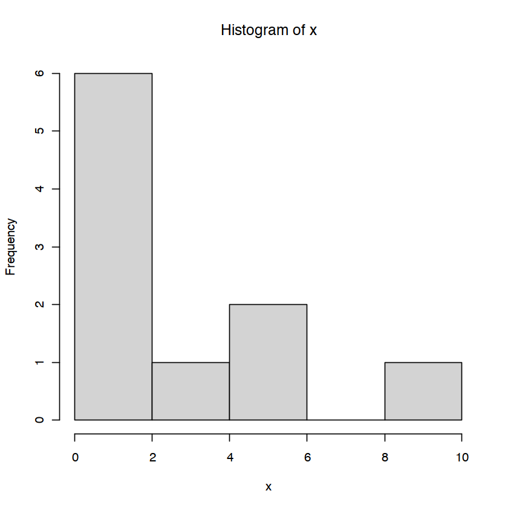

```r
hist(x)$counts
```

`table()` can also be used for analyzing multi-dimensional frequencies:

```r
x  <- c(1, 1, 1, 2, 1, 3, 3, 2, 1, 3)
y  <- c(0, 0, 0, 1, 0, 0, 1, 1, 0, 1)
z  <- c("a", "b", "b", "a", "b", "b", "a", "b", "a", "a")
df <- data.frame(x, y, z)
df
```

A data.frame: 10 × 3

| x <dbl> | y <dbl> | z <chr> |
| --- | --- | --- |
| 1 | 0 | a |
| 1 | 0 | b |
| 1 | 0 | b |
| 2 | 1 | a |
| 1 | 0 | b |
| 3 | 0 | b |
| 3 | 1 | a |
| 2 | 1 | b |
| 1 | 0 | a |
| 3 | 1 | a |

```r
table(x, y, z)
```

```
, , z = a

   y
x   0 1
  1 2 0
  2 0 1
  3 0 2

, , z = b

   y
x   0 1
  1 3 0
  2 0 1
  3 1 0
```

```r
table(df)
```

```
, , z = a

   y
x   0 1
  1 2 0
  2 0 1
  3 0 2

, , z = b

   y
x   0 1
  1 3 0
  2 0 1
  3 1 0
```

> **Exercise**: Computing sums and frequencies

> $$d=(77 \, 93 \, 92\, 68\, 88\, 75\, 100)$$
> - Calculate the mean of $d$, i.e $\bar{d}$.
> - Sort all elements of $d$ in ascending/descending order.
> - What are the smallest and biggest elements of $d$?

```r
d <- c(77, 93, 92, 68, 88, 75, 100)
sort(d)
sort(d, decreasing = TRUE)
mean(d)
sum(d) / length(d)
min(d)
max(d)
```

1. 68

2. 75

3. 77

4. 88

5. 92

6. 93

7. 100

1. 100

2. 93

3. 92

4. 88

5. 77

6. 75

7. 68

84.7142857142857

84.7142857142857

68

100

## Probability distribution

When dealing with random variables, we are mainly interested in four different concepts, namely, we would like to know how

- to find the value of a probability function or a density function at a given point;
- to calculate the probabilities for certain events;
- to determine quantiles;
- perform a simulation study, i.e. how to draw a certain amount of random numbers from a given distribution.

The R functions used for the above purposes are very similar for all distributions. The examples of usage of such functions for a normally distributed random variable and for a random variable from the binomial distribution are given below.

### Normal distribution

There are four R functions that fully cover the operations with a normally distributed random variable: `dnorm()`, `pnorm()`, `qnorm()` and `rnorm()`. Here, "d" stands for density and `dnorm(x)` calculates the value of the probability density function (pdf) at a specified location $x$, "p" stands for probability and `pnorm(x)` gives the value of a cumulative distribution function (cdf) at a point $x$, "q" stands for for quantile and `qnorm(p)` looks up the $p$-th quantile of the normal distribution, and "r" stands for random and `rnorm(n)` draws $n$ random numbers from a normal distribution.

**Example**

```r
x <- rnorm(n=1000)
mean(x)
```

-0.00144316302538041

```r
sd(x)
```

[output not shown]

Due to the symmetry of the normal distribution, the value of the distribution function at the expected value is always 0.5:

```r
pnorm(0)
pnorm(0,1,2)
pnorm(1,1,2)
```

0.5

0.308537538725987

0.5

Now we wolud like to calculate the probability for the interval $[2,3]$ for a $\mathcal{N}(1,4)$- distributed random variable X, i.e. the probability $P(2\leq X \leq 3 )$.

```r
pnorm(3, mean = 1, sd = 2) - pnorm(2, mean = 1, sd = 2)
```

0.14988228479453

What is the 0.6 quantile of the $\mathcal{N}(1,4)$ distribution?

```r
qnorm(0.6, mean = 1, sd = 2)
```

1.5066942062716

What are the 0.25, 0.5, and 0.75 quantiles of the standard normal distribution?

```r
qnorm(c(0.25, 0.5, 0.75), 0, 1)
```

1. -0.674489750196082

2. 0

3. 0.674489750196082

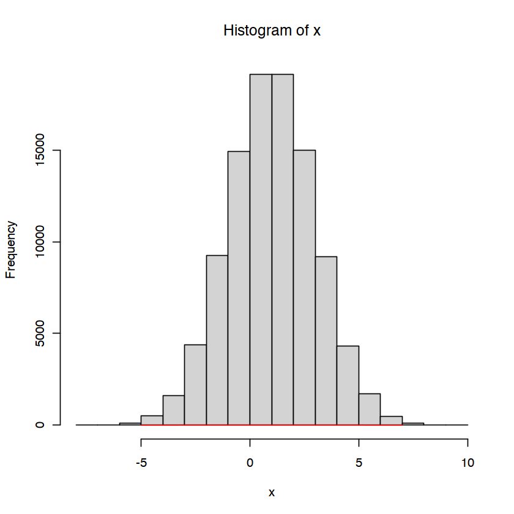

```r
x <- rnorm(100000, 1, 2)
hist(x, freq = TRUE)
?hist
y <- seq(-5, 7, le = 100)
z <- dnorm(y, mean = 1, sd = 2)
lines(y, z, type = "l", col = "red")
```

Now we would like to compare this histogram with the theoretical values:

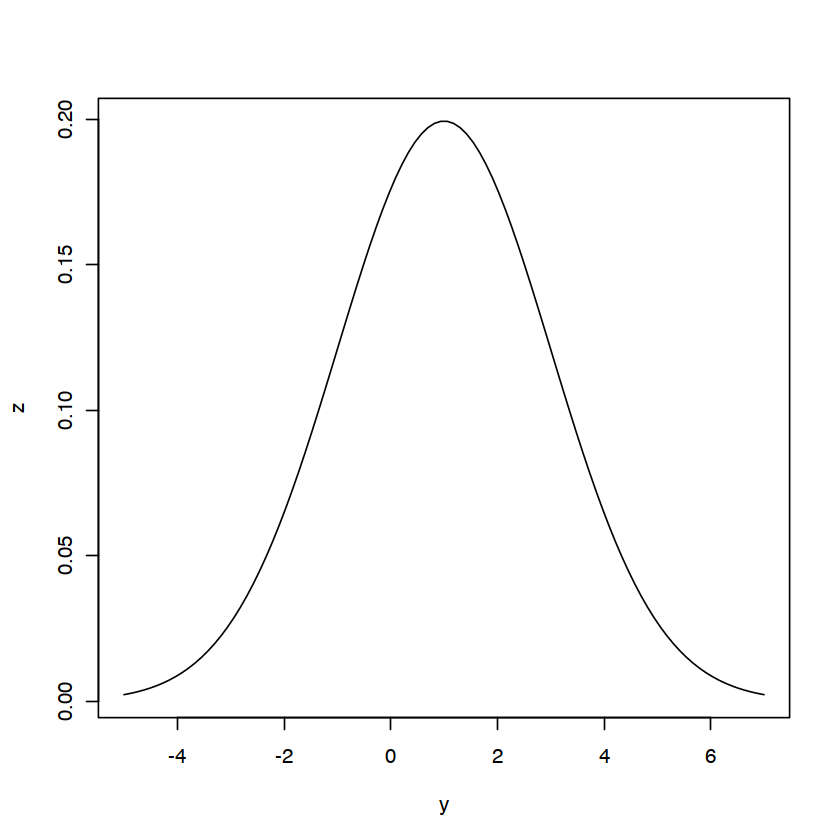

```r
y <- seq(-5, 7, le = 100)
z <- dnorm(y, mean = 1, sd = 2)
plot(y, z, type = "l")
```

We can even do it on one plot.

[figure not shown]

```r
hist(x, prob = TRUE) # show densities instead of frequencies
lines(y, z, type = "l", col = "red")
```

### Binomial distribution

The basic commands are `dbinom()`, `pbinom()`, `qbinom()` and `rbinom()`.

**Example**

Let $X$ be binomial distributed with $n = 10$ (number of trials) and $p = 0.5$ (probability of a success). Basically, this is nothing else than throwing a fair coin $10$ times, then the random variable $X$ specifies the number of "heads" in $10$ throws.

We would like to answer the following question: what is the probability for "exactly 8 times head", i.e. $P(X=8)$?

```r
dbinom(2, 10, 0.5)
```

0.0439453125

What is the probability for $P(2\leq X\leq 6)$?

```r
pbinom(6, 10, 0.5) - pbinom(1, 10, 0.5)
```

0.8173828125

In this case we have to differentiate between $<$ und $\leq$. Why? What are the 0.25- ,0.5- and the 0.75-quantiles of the $\mathcal{B}(10,0.5)$-distribution?

```r
qbinom(c(0.25, 0.5, 0.75), 10, 0.5)
```

1. 4

2. 5

3. 6

How can we simulate a 20-time coin toss?

```r
rbinom(20, 1, 0.5)
rbinom(1, 20, 0.5)
```

1. 0

2. 0

3. 1

4. 1

5. 0

6. 1

7. 1

8. 0

9. 0

10. 0

11. 1

12. 1

13. 1

14. 0

15. 0

16. 1

17. 1

18. 0

19. 0

20. 1

12

This corresponds to the 20-fold repetition of a Bernoulli experiment, i.e. the 20-time draw from a $\mathcal{B}(1, 0.5)$ distribution. The number of zeros/ones is then $\mathcal{B}(20, 0.5)$-distributed. The probability function of this distribution can be represented as follows.

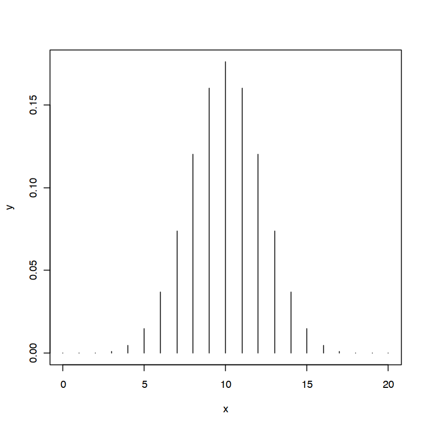

```r
x <- 0:20
y <- dbinom(x, 20, 0.5)
plot(x, y, type="h")
```

In R, there are similar commands for many other distributions, e.g. `dgamma()`, `dexp()`, `dpois()`, `dunif()`, etc.

## Reproducibility

Usually the "random generator" in R draws new number for each call of a random generating function, that is, for each run of the function `rnorm()` and alike, the results will be different. In order to have exactly the same results each time, we need to somehow fix the "location" at which the random generator starts. We can do that with `set.seed()` function. Setting the seed is equilvalent to manipulating the data generating process so that a particular sample can be replicated.

```r
set.seed(123)
rbinom(10,1,0.5)
set.seed(123)
rbinom(10,1,0.5)
```

1. 0

2. 1

3. 0

4. 1

5. 1

6. 0

7. 1

8. 1

9. 1

10. 0

1. 0

2. 1

3. 0

4. 1

5. 1

6. 0

7. 1

8. 1

9. 1

10. 0

But this is different compare to

```r
set.seed(10)
rbinom(10,1,0.5)
rbinom(10,1,0.5)
```

1. 1

2. 0

3. 0

4. 1

5. 0

6. 0

7. 0

8. 0

9. 1

10. 0

1. 1

2. 1

3. 0

4. 1

5. 0

6. 0

7. 0

8. 0

9. 0

10. 1

> **Exercise 1:** Random variables

> Consider this multiple choice test:

> 12 Questions 5 possible answers, only one of them is correct.

> If the answers are chosen completely at random, then
> - what is the probability of exactly four correct answers?
> - what is the probability of four or fewer correct answers?

> **Exercise 2**

> Assume that the number of points for an exam (for all of the students) is a random variable $X$ that is normally distributed with $\mu=72$ and $\sigma=15.2$.
> - What is the proportion of students that have 84 or more points (on average).
> - $1000$ Students take the exam. Simulate the results, calculate $\hat{\mu} =\bar{x}$ and $\hat{\sigma}$ (with function `sd()`).

> **Exercise 3**

> Generate 1000 random numbers on the interval between $a=-1$ und $b=1$ with

> $$f(x) =\begin{cases}\frac{1}{b-a} \quad &\mbox{if} \quad a\leq x \leq b,\\ 0 \quad \mbox{if} \quad x<a \quad &\mbox{or} \quad x>b. \end{cases}$$

```r
# Exercise 1
dbinom(4, size =12, prob=0.2) #density function
pbinom(4, size=12, prob=0.2) #cumulative distribution function
```

0.13287555072

0.92744450048

```r
# Exercise 2
pnorm(84, mean = 72, sd = 15.2, lower.tail = FALSE)

# Or
1 - pnorm(84, mean = 72, sd = 15.2, lower.tail = TRUE)
S <- rnorm(1000, 72, 15.2)
mean(S)
sd(S)
```

0.214917602311272

0.214917602311272

71.7737359606113

15.3108233337365

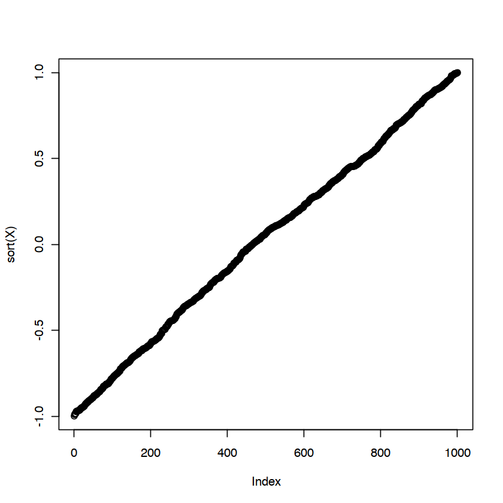

```r
#Exercise 3
X <- runif(1000, -1, 1)
plot(sort(X))
```

# Simple programming

## Loops

Often we want to repeat a particular operation many times: either over different elements of a given data structure (columns of a matrix, individual elements of a vector), or perform an operation until a satisfactory result is reached (run an algorithm until the value "stabilizes", i.e. stays in a prespecified level of a constant). There are many ways to deal with it. The simplest was to run a chunk of code multiple times is to use a so-called "for loop".

*Note: Before we dive into writing loops in R, there is one important thing you should know. When surfing on the web, you’ll often read that one should avoid making use of loops in R. Why? The reason is that R supports vectorization which allows for much faster calculations. For example, solutions that make use of loops are less efficient than vectorized solutions that make use of `apply` functions, such as `lapply` and `sapply`. It’s often better to use the latter. Nevertheless, as a beginner in R, it is good to have a basic understanding of loops and how to write them. If you want to learn more on the concepts of vectorization in R, [this](http://www.noamross.net/archives/2014-04-16-vectorization-in-r-why/) is a good read.*

```r
x <-0

for (i in 1:10) {
    cat("i =", i)
    x <- x + i
    cat(", x =", x, "\n")
}

vec <- 1:10
vec2 <- cumsum(vec)
vec2
```

```
i = 1, x = 1
i = 2, x = 3
i = 3, x = 6
i = 4, x = 10
i = 5, x = 15
i = 6, x = 21
i = 7, x = 28
i = 8, x = 36
i = 9, x = 45
i = 10, x = 55
```

1. 1

2. 3

3. 6

4. 10

5. 15

6. 21

7. 28

8. 36

9. 45

10. 55

What happens here?

We can also perform similar calculations with a vector and store the results in a matrix:

```r
z <- matrix(NA, nrow = 3, ncol = 2)
z
x <- c(0, 1)
for (i in 1:3) {
    x <- x + i
    z[i,] <-x
}
x
z
```

A matrix: 3 × 2 of type lgl

| NA | NA |
| --- | --- |
| NA | NA |
| NA | NA |

1. 6

2. 7

A matrix: 3 × 2 of type dbl

| 1 | 2 |
| --- | --- |
| 3 | 4 |
| 6 | 7 |

In the next example, we carry out a simulation study based on the law of large numbers. We would like to show that with increasing sample size "large" deviations of the sample mean $\bar{X}$ from the expected value $\mathbb{E}[X]$ become smaller and smaller.

We will draw samples (with different sample sizes) from a Bernoulli distribution, that is, $ X \sim\mathcal{B}(1, 0.5)$-distribution that simulates the tossing of a fair coin. The sample mean, which results from zeros and ones, corresponds in this case to the relative proportion of the ones. This relative fraction would converge stochastically to 0.5, because the expected value of a $\mathcal{B}(1, 0.5)$ random variable is equal to $0.5$.

```r
relative_share <- c() #Initialize an "empty vector" where we can store the results
N <- 5000              #Maximum sample size
for (n in 1:N) {      #The loop itself: everything inside is repeated N times
    sample <- rbinom(n, 1, 0.5) #draw a vector with sample size n
    relative_share <- c(relative_share, mean(sample)) #calculate the proportion of the ones
                                                      #and write them to the end of the vector
}

#plot(1:N, relative_share, #plot the results of all samples
#     main = "B(1, 0.5)-Distribution: Law of large numbers", #text
#     xlab = "n", ylab = "Relative proportion", pch = 16,
#     cex.axis=1.5, cex.lab = 1.5, cex.main = 1.5)
#abline(h = 0.5, lwd = 2, col = 2) #We add a line for the expected value
```

## Conditions

Sometimes, we have to check whether a condition about the data is fulfilled, e.g. are elements of a vector smaller than 0, and based on the result, we would like to perform different operations. Moreover, within a for-loop, it may be useful to perform arithmetic operations only under certain conditions. For that we need a conditional `if...else` statement.

The basic syntax of an `if` statement is

```
{r, eval = FALSE}
if (condition) {
     statement
} else {
     alternative
}
```

where `else` can remain unspecified.

```r
y    <- c(1, 4, 5, 2, 7, 8, 2, 4)
N    <- length(y)
y.sq <- numeric(N)#creates an empty numeric vector of length N
for(i in 1:N) {
    y.sq[i] <- y[i]^2 #every element of y.sq is equal to the respective squared value of the element of y.
    if (i == N) {     #only when this condition is met, i.e. only in the last iteration of the loop, we print y.sq
        print(y.sq)
    } else {          #in all of the other iterations of the loop, we print "not finished"
        print("not finished")
    }
}
```

```
[1] "not finished"
[1] "not finished"
[1] "not finished"
[1] "not finished"
[1] "not finished"
[1] "not finished"
[1] "not finished"
[1]  1 16 25  4 49 64  4 16
```

There is also a shorter form `ifelse()`:

```r
y    <- c(1, 4, 5, 2, 7, 8, 2, 4)
N    <- length(y)
y.sq <- numeric(N)#creates an empty numeric vector of length N
for(i in 1:N) {
    y.sq[i] <- y[i]^2 #every element of y.sq is equal to the respective squared value of the element of y.
    ifelse (i == N, print(y.sq), print("not finished"))
                      #only when i = N, i.e. only in the last iteration of the loop, we print y.sq
}
```

```
[1] "not finished"
[1] "not finished"
[1] "not finished"
[1] "not finished"
[1] "not finished"
[1] "not finished"
[1] "not finished"
[1]  1 16 25  4 49 64  4 16
```

## The while loop

Besides a `for` loop, there are other way to write a loop in R. For example, the `while` loop performs a program ("statement") as long as certain data conditions ("test_expression") are met. The basic syntax is

```
{r, eval = FALSE}
while (test_expression)
{
    increment i (or perform other manipulations with the data)
    statement
}
```

Here, `test_expression` is evaluated and the body of the loop is executed if the result is `TRUE`. There is a possibility that the `statement` inside of a `while` loop is never executed (if the `test_expression` is not satisfied from the very beginning).

```r
i <- 2
results <- c()
while (i < 6) {
    print(i)
    x <- i
    results <- c(results, i)
    i <- i + 1
}
x
results
```

```
[1] 2
[1] 3
[1] 4
[1] 5
```

5

1. 2

2. 3

3. 4

4. 5

In the above example, $i$ is initially initialized to $2$. In the first iteration, the `test_expression` is `TRUE` since $2$ is less than $6$. This means that we enter the body of the loop, where we (a) print $i$; (b) assign the value of $i$ to $x$; (c) append the value of $i$ to the vector `results`; and (d) increment $i$.

In the next iteration, the value of $i$ is $3$ and the loop continues until $i$ takes the value $6$. The condition $6 < 6$ will result in `FALSE` and the `while` loop finally exits.

Incrementing $i$ (or any other operation with the data that is involved in `test_expression`) is very important as this will eventually be our exit condition. Failing to do so, will result in an infinite loop.

There is one other loop that can be used in R, `repeat`. You can read more about this type of loops by running `?repeat` in R.

> **Exercise 1:** For loops

> Using the variables $x=1$ and $y=40$, write a `for()` loop that increments x by three and decreases y by two ten times.

> **Exercise 2:** While loops

> Using the vectors $a = (15, 14, \ldots, 10)$ and $b = (20, 19, \ldots, 15)$, write a `while()` loop that computes a vector $x = (225, 224, 221, 216, 209, 200)$, such that
> - `x[1] = a[1] * b[6]`
> - `x[2] = a[2] * b[5]`
> - `x[3] = a[3] * b[4]`
> - $\ldots$
> - `x[6] = a[6] * b[1]`

```r
#Exercise 1
x <- 1
y <- 40
for (i in 1:10){
  x <- x + 3
  y <- y - 2
}
x
y
```

31

20

```r
a <- 15:10
b <- 20:15
x <- vector(mode = "numeric", length = length(a))
i = 0
while (i<length(a)) {
  i <- i + 1
  x[i] <- a[i] * b[length(a) - i + 1]
}
x
```

1. 225

2. 224

3. 221

4. 216

5. 209

6. 200

# Functions

## Basic functions

Functions are sets of instructions that you want to use repeatedly or that, because of their complexity, are better self-contained in a sub program and called when needed. A function is a piece of code written to carry out a specified task; it may or may not accept arguments and it may or may not return one or more values.

The instructions inside of a function are only executed when the function is called.

[output not shown]

It is possible to set the default values of the argument so that the user do not need to specify it.

Function can return only one object (or if they may not return anything), but it is also possible to return multiple values by using a list as a return object.

As an example, we will look at the sample variance

$$s^2=\frac{1}{n-1}\sum_{i=1}^n(x_i-\bar{x})^2.$$

For the sake of simplicity, we will use the the biased sample variance $\hat{\sigma}^2$, that is nothing else but $s^2$ multiplied by $\frac{n-1}{n}$:

$$\hat{\sigma}^2=\frac{n-1}{n}s^2 =\frac{1}{n}\sum_{i=1}^n(x_i-\bar{x})^2=\frac{1}{n} \sum_{i=1}^nx_i^2 - \bar{x}^2$$

```r
vartilde <- function(x) {
    mean(x^2) - mean(x)^2
}
```

```r
y <- rnorm(10000)
vartilde(y)
var(y)
(length(y) - 1)/length(y) * var(y)
```

1.0099401647883

1.01004116890519

1.0099401647883

```r
vartilde <- function(x){
    var <- mean(x^2) - mean(x)^2
    a   <- "normalizing by n, not (n-1)"
    return(list(variance = var, writing = a))
}
```

```r
z <- rnorm(100)
vartilde(z)
```

**$variance**

0.925403295635461

**$writing**

'normalizing by n, not (n-1)'

```r
vartilde(x)
```

**$variance**

0.996759120052337

## Functions with multiple arguments

Functions can also have multiple arguments. As an example, we write the illustration of the law of large numbers from the previous using a function.

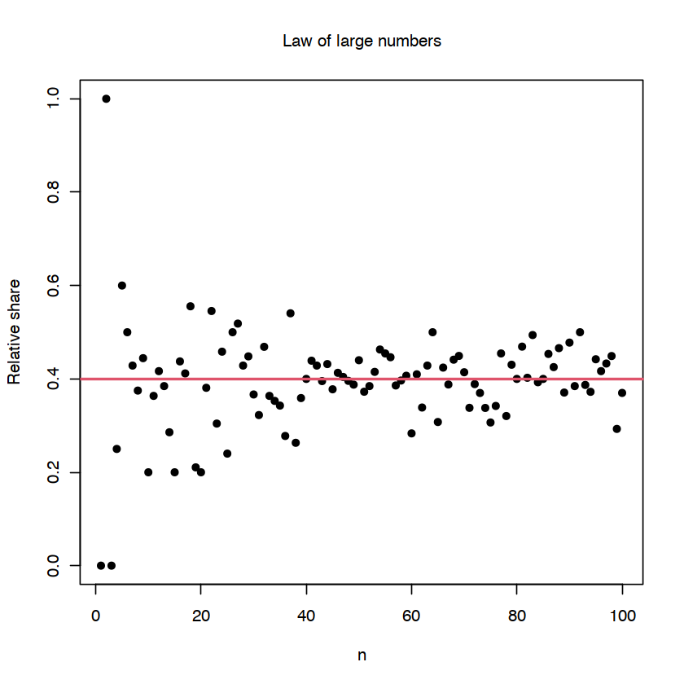

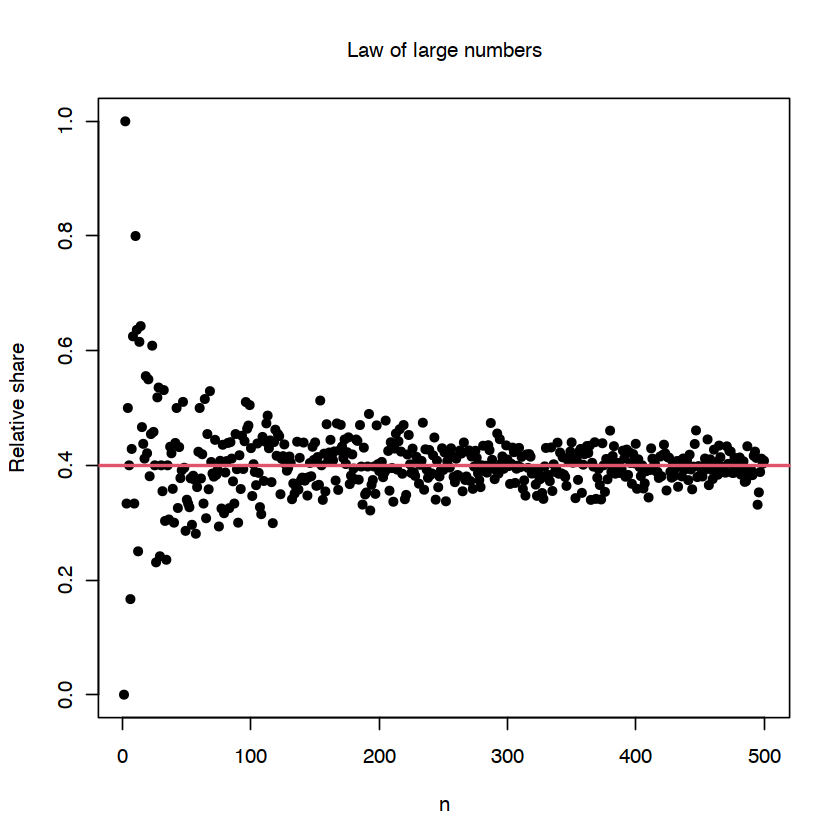

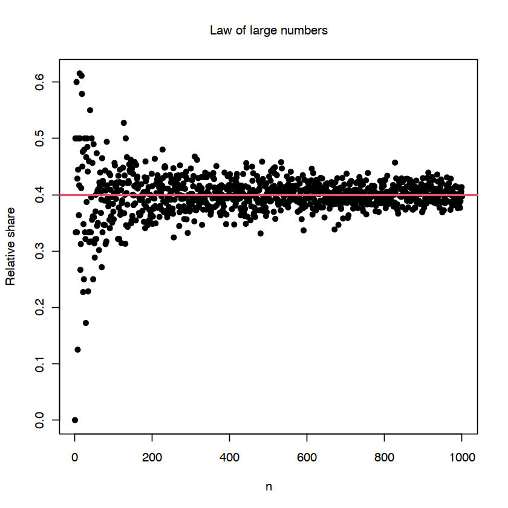

```r
LLN_Graph <- function(N, p) {
    relative_share <- c()
    for (n in 1:N) {
        sample <- rbinom(n, 1, p)
        relative_share <- c(relative_share, mean(sample))
    }
    plot(1:N, relative_share,
         main = "Law of large numbers",
         xlab = "n", ylab = "Relative share", pch = 16,
         cex.axis = 1, cex.lab = 1, cex.main = 1)
    abline(h = p, lwd = 2, col = 2)
}

LLN_Graph(N = 100, p = 0.4)
LLN_Graph(N = 500, p = 0.4)
LLN_Graph(N = 1000, p = 0.4)
```

## Functions with multiple outputs

The function may not return anything as an output (as in the examples above), then the last computation in the function is often printed to the console. If the function needs to return something (for example, to assign this value further to some variable), then we need to explicitly write the `return` statement in the end of a body of the function. `return` can be used with a list, a variable, a vector, a matrix, etc.

Let's look again at `LLN_graph` function from the previous example. Suppose we would like not only to have a look at the plot, but to store all of the relative shares as well. Suppose we would also like to calculate the fraction of all sample means that lie in a prespecified interval $(a, b)$, where $a$ and $b$ are supplied by the user.

```r
LLN_Sim <- function(N = 100, p = 0.5, a = 0, b = 1) {
    relative_share <- c()
    for (n in 1:N) {
        sample <- rbinom(n, 1, p)
        relative_share <- c(relative_share, mean(sample))
    }
   int_fraction  <- sum(a < relative_share & relative_share < b) / N
   return(list(rel = relative_share, int_fraction = int_fraction))
}
```

```r
result   <- LLN_Sim(100, p = 0.6, a = 0.4, b = 0.6)
interval <- result$int_fraction

dummy <- function(N = 100, p = 0.6, a = 0.4, b = 0.6){
    interval <- LLN_Sim(N, p, a, b)$int_fraction
    ifelse(interval > 0.45, "yes", "no")
}
```

```r
dummy()
```

'yes'

Functions can also be arguments to another function.

> **Exercise 1:** Functions

> Write a function that takes one argument: a vector that consists of a name and a surname. The function should take the first element of this vector and return it and a sentence: "My first function".

> **Exercise 2**
> 1. Draw a vector $u$ with length 30 from $\mathcal{N}=(0,1)$.
> 2. Calculate $u^2$ for the first k=10 values in u (and print it to the console).
> 3. Calculate $u^2$ for the first k=10 values in u only when $|u|>l$ for $l=0.8$ (and print it to the console), otherwise print the original value.
> 4. Write a function that takes three arguments ($u,k,l$) and returns two results: a vector of length($k$) with the result of the calculation $u^2$ by the rule (3) where $l$ is supplied by the user, and a scalar indicating the number of elements of $u$ for which the condition is fulfilled.

```r
#Exercise 1

my.first.function <- function(name) {
  init <- name[1]
  statement <- "My first function"
  return(list(init = init, statement = statement))
}

my.first.function(c("Marina", "Khismatullina"))
```

**$init**

'Marina'

**$statement**

'My first function'

```r
#Exercise 2

#1
# Create a vector filled with random normal values
u1 <- rnorm(30)
u1

#2
print("This loop calculates the square of the first 10 elements of vector u1")
# Initialize `usq`
usq <- numeric(10)
for(i in 1:10) {
  # i-th element of `u1` squared into `i`-th position of `usq`
  usq[i] <- u1[i] * u1[i]
  print(usq[i])
}

#3
print("This loop calculates the square of the first 10 elements of vector u1 if the condition is met")
# Initialize `usq`
usq <- numeric(10)
for(i in 1:10) {
  if (abs(u1[i])>0.8) { #Checking if |u| > 0.8
    # i-th element of `u1` squared into `i`-th position of `usq`
    usq[i] <- u1[i]*u1[i]
  } else {
    usq[i]<-u1[i]
  }
  print(usq[i])
}

#4
usquared <- function(u,k,l) {
  cat("This loop calculates the square of the first", k, " elements of vector u for which |u| > ", l, "\n")
  # Initialize `usq`
  usq <- numeric(k) #empty vector of length k
  for(i in 1:k) {
    if(abs(u[i]) > l) { #if the condition is met
      # i-th element of `u1` squared into `i`-th position of `usq`
      usq[i] <- u[i]*u[i]
    } else {
      usq[i]<-u[i]
    }
  }
  z <- sum(abs(u[1:k])> l)
  return(list(usq = usq, z = z))
}

result <- usquared(u1, 20,0.5)
result$usq
result$z
result
```

1. -0.850253791420922

2. 0.426037973878133

3. 0.668261156410619

4. -1.97796661712897

5. -0.280577303652893

6. 0.898986683295212

7. 1.90031737162526

8. 1.48765220623164

9. -3.16677852868324

10. -0.951722647162746

11. -1.27655556097638

12. 0.397073585700503

13. -0.560765973461268

14. 0.092577443636219

15. 1.10287047340614

16. 1.23226008843866

17. 0.0550341220716281

18. 1.66063832324319

19. 0.388738607459266

20. -0.820686043749637

21. 0.708074053180569

22. -0.883092272861186

23. -1.7332898579598

24. 1.43186485445771

25. 0.185371172533171

26. 0.517595273671413

27. 1.24466893405652

28. 1.60848490337881

29. 1.07649888936171

30. 0.187316594236775

```
[1] "This loop calculates the square of the first 10 elements of vector u1"
[1] 0.7229315
[1] 0.1815084
[1] 0.446573
[1] 3.912352
[1] 0.07872362
[1] 0.8081771
[1] 3.611206
[1] 2.213109
[1] 10.02849
[1] 0.905776
[1] "This loop calculates the square of the first 10 elements of vector u1 if the condition is met"
[1] 0.7229315
[1] 0.426038
[1] 0.6682612
[1] 3.912352
[1] -0.2805773
[1] 0.8081771
[1] 3.611206
[1] 2.213109
[1] 10.02849
[1] 0.905776
This loop calculates the square of the first 20  elements of vector u for which |u| >  0.5
```

1. 0.722931509825653

2. 0.426037973878133

3. 0.446572973167257

4. 3.91235193847661

5. -0.280577303652893

6. 0.808177056742126

7. 3.61120611290074

8. 2.21310908670586

9. 10.0284862497292

10. 0.905775997122465

11. 1.62959410025971

12. 0.397073585700503

13. 0.314458476991963

14. 0.092577443636219

15. 1.21632328111109

16. 1.51846492555887

17. 0.0550341220716281

18. 2.75771964062394

19. 0.388738607459266

20. 0.67352558240543

14

**$usq**

1. 0.722931509825653

2. 0.426037973878133

3. 0.446572973167257

4. 3.91235193847661

5. -0.280577303652893

6. 0.808177056742126

7. 3.61120611290074

8. 2.21310908670586

9. 10.0284862497292

10. 0.905775997122465

11. 1.62959410025971

12. 0.397073585700503

13. 0.314458476991963

14. 0.092577443636219

15. 1.21632328111109

16. 1.51846492555887

17. 0.0550341220716281

18. 2.75771964062394

19. 0.388738607459266

20. 0.67352558240543

**$z**

14

[figure not shown]